# Getting Started with BiblioKit

Rie Matsumoto, STEaPP, UCL

2024-08-14

## About the package

This package offers tools for analyzing and visualizing bibliometric data from academic literature. It includes functions for extracting and processing citation data, generating keyword co-occurrence networks, and producing authorand publication statistics. The package aims to assist researchers in exploring trends and patterns in scientific publications.

## Setup

To use the Bibliokit library, you need a Scopus API account. If you have not set up your API key yet, you need to sign up your Scopus API account and set it up for your device. Follow the instruction of `rscopus` library. By using have_apr_key() function (a simple wrapper of the same-name function of `rscopus` library), you can check if you already have a proper API key.

When you have a Scopus API key, please load BiblioKit library!

```r
library( bibliokit )
```

## Search

The `expand_search_terms()` function takes one or more initial search terms and returns a query (expanded set of terms) by including related or similar terms. The expansion helps to capture more relevant results by broadening the search.

```r
expanded_terms <- bibliokit::expand_search_terms( "quantum computer" )
```

By using this function with the naive search term `quantum computer`, you can obtain the following terms, which can be used for your search.

```r
expanded_terms
```

```
#>  [1] "optimization"      "quantum computing" "classical"         "computer"          "computers"         "computing"         "effect"
#>  [8] "learning"          "noisy"             "performance"       "process"           "quantum"           "quantum computer"  "quantum computers"
#> [15] "qubit"
```

You can pick up some related terms for your final search terms. If you would like to make structured search query, you can use functions of `litsearchr` library.

Then you can conduct the search for your final term. The download_scopus_data() function retrieves bibliographic records from the Scopus API for the past N years.

```r
res <- bibliokit::download_scopus_data( c("quantum computer", "quantum computing" ), n = 10 )
```

```r
summary( res )
```

```
#>                Length Class  Mode
#> entries        10476  -none- list
#> meta_data          7  -none- list
#> get_statements   130  -none- list
```

The list `res$entries` contains the bibliographical data or yielded articles. It includes the article title, the journal name, details on authors and affiliations, and other information.

```r
names( res$entries[[1]] )
```

```
#>  [1] "@_fa"                   "link"                   "prism:url"              "dc:identifier"          "eid"                    "dc:title"
#>  [7] "dc:creator"             "prism:publicationName"  "prism:issn"             "prism:eIssn"            "prism:volume"           "prism:issueIdentifier"
#> [13] "prism:pageRange"        "prism:coverDate"        "prism:coverDisplayDate" "prism:doi"              "dc:description"         "citedby-count"
#> [19] "affiliation"            "prism:aggregationType"  "subtype"                "subtypeDescription"     "author-count"           "author"
#> [25] "authkeywords"           "article-number"         "source-id"              "fund-no"                "openaccess"             "openaccessFlag"
```

## Basic Rankings

Now that you have your own data, you can analyse it with various functions. Here you can see the example using the search result of `"quantum computing"`.

First of all, you can generate basic rankings from the obtained data.

### Keywords

The `rank_keywords()` function generates a ranking of the top keywords from the provided Scopus search results, based on the number of publications and total citations. By setting the `abst = TRUE` option, the function can include not only the keywords tagged by the authors but also the abstracts of the papers in the ranking. The output is a tibble with the following columns: `rank` rank of the keyword, `keyword` the keyword, and `n` number of publications with the keyword.

```r
bibliokit::rank_keywords( res, n = 5 )
```

```
#> # A tibble: 5 × 3
#>    rank keyword                       n
#>   <int> <chr>                     <int>
#> 1     1 quantum computing          3567
#> 2     2 quantum machine learning    335
#> 3     3 machine learning            267
#> 4     4 quantum annealing           197
#> 5     5 post-quantum cryptography   170
```

### Authors

The `rank_authors()` function generates a ranking of the top authors from the provided Scopus search results, based on the number of publications and total citations. By setting the `include_all = TRUE` option, the function can include not only the first authors but also all authors of the publications in the ranking. The output is a tibble with the following columns: `rank` rank of the author, `name` author’s name, `n_publications` number of publications, `n_citations` total number of citations, `institution` author’s primary institution, and `country` author’s country.

```r
bibliokit::rank_authors( res, n = 5 )
```

```
#> # A tibble: 5 × 7
#>    rank id          name        n_publications n_citations institution                                              country
#>   <int> <chr>       <chr>                <int>       <dbl> <chr>                                                    <chr>
#> 1     1 9732839200  Acampora G.             22         143 Istituto Nazionale di Fisica Nucleare, Sezione di Napoli Italy
#> 2     2 8952130000  Morimae T.              16         300 NTT Social Informatics Laboratories                      Japan
#> 3     3 51061778800 Yan F.                  12         375 Tokyo Institute of Technology                            Japan
#> 4     4 37012494000 Dey S.                  12         212 Cooch Behar Government Engineering College Cooch Behar   India
#> 5     5 57200913750 Orts F.                 12          64 Vilniaus Universitetas                                   Lithuania
```

```r
bibliokit::rank_authors( res, n = 5, include_all = TRUE )
```

```
#> # A tibble: 5 × 7
#>    rank id          name             n_publications n_citations institution                               country
#>   <int> <chr>       <chr>                     <int>       <dbl> <chr>                                     <chr>
#> 1     1 24587880100 Wille R.                     61         841 Technische Universität München            Germany
#> 2     2 6602287338  Humble T.S.                  55         770 Oak Ridge National Laboratory             United States
#> 3     3 7006555837  Chong F.T.                   50        1405 School of Engineering and Applied Science United States
#> 4     4 6603792591  Charbon E.                   43        1433 École Polytechnique Fédérale de Lausanne  Switzerland
#> 5     5 7402157487  Bhattacharyya S.             41         398 Christ University                         India
```

### Affiliations

The `rank_affiliations()` function generates a ranking of the top affiliations from the provided Scopus search results, based on the number of publications and total citations. By choosing the `type = "city"` or `type = "institution"` option, the function can provide the ranking of cities or institutions instead of countries. The output is a tibble with the following columns: `rank` rank of the affiliation, `country/city/institution` type of the affiliation, and `n` number of publications.

```r
bibliokit::rank_affiliations( res, n = 5 )
```

```
#> # A tibble: 5 × 3
#>    rank country            n
#>   <int> <chr>          <int>
#> 1     1 United States   5304
#> 2     2 China           3760
#> 3     3 India           1998
#> 4     4 Germany         1447
#> 5     5 United Kingdom  1051
```

```r
bibliokit::rank_affiliations( res, n = 5, type = "city" )
```

```
#> # A tibble: 5 × 3
#>    rank city                          n
#>   <int> <chr>                     <int>
#> 1     1 Beijing, China             1127
#> 2     2 Tokyo, Japan                371
#> 3     3 Singapore City, Singapore   365
#> 4     4 Shanghai, China             305
#> 5     5 Hefei, China                297
```

```r
bibliokit::rank_affiliations( res, n = 5, type = "institution" )
```

```
#> # A tibble: 5 × 3
#>    rank institution                                              n
#>   <int> <chr>                                                <int>
#> 1     1 University of Science and Technology of China, China   151
#> 2     2 Tsinghua University, China                             150
#> 3     3 University of Oxford, United Kingdom                   135
#> 4     4 University of Chinese Academy of Sciences, China       127
#> 5     5 Oak Ridge National Laboratory, United States           121
```

### Sponsors

```r
bibliokit::rank_sponsors( res, n = 5 )
```

```
#> # A tibble: 5 × 8
#>    rank sponsor                                                    n_publications n_citations cite_per_pub n_countries country_display               country_list
#>   <int> <chr>                                                               <int>       <dbl>        <dbl>       <int> <chr>                         <list>
#> 1     1 National Natural Science Foundation of China (NSFC)                   764        8409         11.0          23 China(687), United States(16… <chr [23]>
#> 2     2 National Science Foundation (NSF)                                     702       26425         37.6          29 United States(617), China(15… <chr [29]>
#> 3     3 Horizon 2020 Framework Programme (H2020)                              302        7289         24.1          30 France(43), United Kingdom(3… <chr [30]>
#> 4     4 U.S. Department of Energy (USDOE)                                     288        6014         20.9          19 United States(245), Canada(7… <chr [19]>
#> 5     5 Engineering and Physical Sciences Research Council (EPSRC)            133        3800         28.6          18 United Kingdom(100), France(… <chr [18]>
```

## Data Visualisation

### Countries

The `plot_country_overview()` function analyses and visualise the countries associated with publications from Scopus search results.

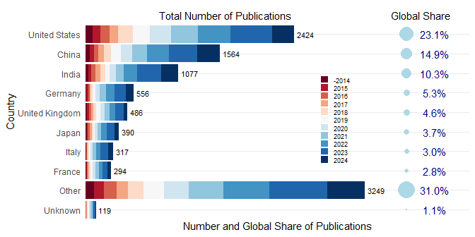

```r
bibliokit::plot_country_overview( res )
```

The `plot_country_trend()` function analyses and visualizes the annual publication trends for countries from Scopus search results.

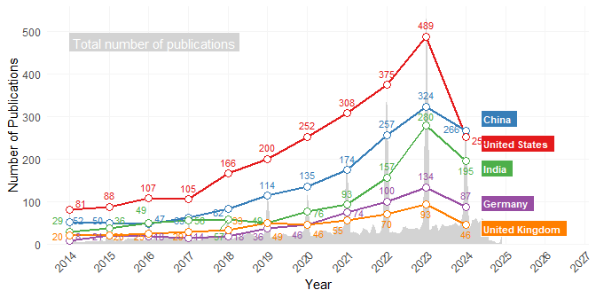

```r
bibliokit::plot_country_trend( res )
```

### Sponsors

The `plot_sponsor_overview()` function analyses and visualise the sponsors from Scopus search results..

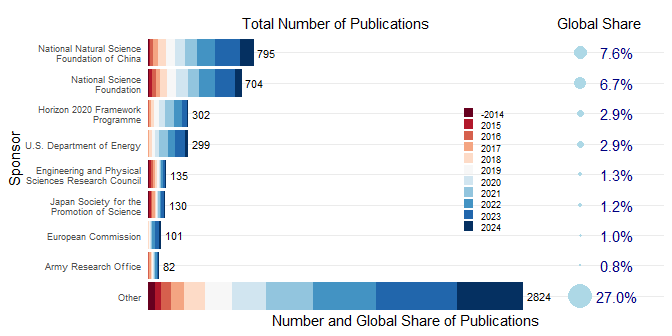

```r
bibliokit::plot_sponsor_overview( res )
```

The `plot_sponsor_trend()` function analyses and visualizes the annual publication trends for sponsors from Scopus search results.

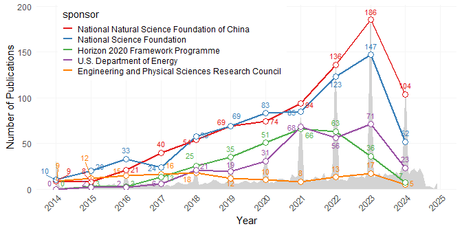

```r
bibliokit::plot_sponsor_trend( res )
```

### Author Numbers

The `plot_authnum_trend()` function analyses and visualizes the annual publication trends for the number of authors from Scopus search results. You can specify `type` of the output from `line`, `stack` and `ratio`.

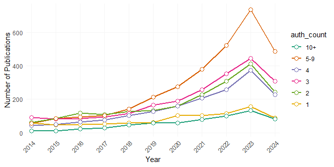

```r
bibliokit::plot_authnum_trend( res )
```

### Country Pairs

The `plot_country_pairs_trend()` function analyses and visualizes the annual publication trends for country pairs from Scopus search results. You can filter the result with a target country by specifying `target_country`.

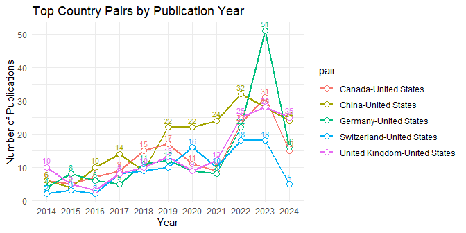

```r
bibliokit::plot_country_pairs_trend( res )
```

## Social Network Analysis

Last but not least, you can perform social network analysis (SNA) using this library. For effective SNA, datasets with more than 10,000 records can be quite large, so we’ll use a smaller dataset with $n = 330$ for demonstration purposes. This data was generated using the keyword `"quantum computing" AND "performance" AND "noisy"`, which was derived from the terms obtained with the `expand_search_terms()` function.

```r
load( "../inst/extdata/sample_data_quantum_noisy.rda" )
```

### SNA between Topics and Countries

The `sna_topic_country()` function analyses a network analysis based on topics (keywords) and countries from the given publication data. It visualizes the relationship between different topics and the countries associated with those topics.

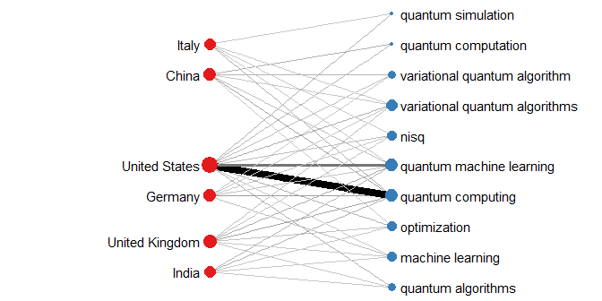

```r
bibliokit::sna_topic_country( res )
```

### SNA among Countries

The `sna_countries()` function analyses co-occurrence data between countries based on shared keywords and creates a network graph visualizing the relationships between countries. The network is constructed based on the frequency of shared keywords between countries. The resulting graph can help in understanding how countries are connected through common research topics.

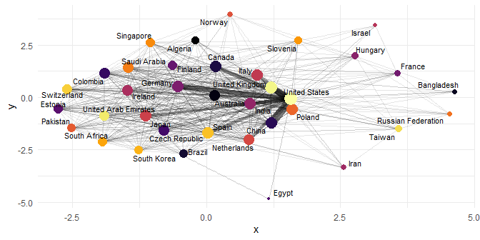

```r
bibliokit::sna_countries( res )
```